# Course Goals

- Develop intermediate data management and analysis skills in R

–

- Learn basic programming

–

- Introduce reproducible research practices

–

- Prepare you for statistics and CSSS courses

# Logistics

Location: * Lecture: SAV117 on Wednesdays, 3:30-5:20 * Optional Lab: SAV117 on Mondays, 3:30-5:20 * Office Hours: SAV255 by Appointment

Materials: http://clanfear.github.io/CSSS508

Grading: * Final grade: C/NC, 60% to get Credit * **Homework** most weeks (75% of grade), combination of reading and programming * **Peer Grading** of homeworks (25% of grade) * Both handed in via Canvas.

# Peer grading, really?

–

## **35+ students, no TA**

## You will write your reports better knowing others will see them

## Learn new tricks from reading others’ code; “appreciate the little things”

### Format:

- Randomly assigned peers, turnaround time: 1 week (due before next class)
- You’ll get a rubric and are expected to leave constructive comments
- High scoring assignments may be adapted into keys (with your permission)
- **Email me** if you want more feedback

# Using the Mailing List

Don’t ask like this:

> tried lm(y~x) but it iddn’t work wat do

–

Instead, ask like this:

> ```
> y <- seq(1:10) + rnorm(10)
> x <- seq(0:10)
> model <- lm(y ~ x)
> ```

> Running the block above gives me the following error, anyone know why?

> ```
> Error in model.frame.default(formula = y ~ x,
> drop.unused.levels = TRUE) : variable lengths differ
> (found for 'x')
> ```

# Slack Channel

This term I experimenting with a [Slack Channel](https://uwcsss508au18.slack.com/) for class communication.

Use it like the mailing list to ask questions, particularly for simple questions.

Use the mailing list for long questions or those requiring you to attach a file.

In addition, I encourage you to use Slack *during class* to ask quick questions of other students and share links.

# A Note on Slide Formatting

**Bold** usually indicates an important vocabulary term. These are terms to remember!

–

*Italics* indicate emphasis but also are used to point out things you must click with a mouse, for example: “Please click *File > Print*”

–

`Code` usually represents R code you might type into the editor or console or keystrokes used to perform actions, for example: “Please press `Ctrl-P` to open the print dialogue.”

–

Code chunks that span the page like the one below represent *actual R code that runs inside these slides*.

```r
# Sometimes important stuff is highlighted! #<<
7 * 49
```

```
## [1] 343
```

The lines preceded by `##` represent the output, or result, of running the code in the code chunk. We’ll talk about this more later!

# Lecture Plan

## 1. Intro to R, RStudio, and R Markdown

## 2. Plotting with `ggplot2`

## 3. Summarizing and Combining Data: `dplyr`

## 4. R Data Structures

## 5. Data Cleaning: Import/Export, `tidyr`, Dates

## 6. Loops and Functions

## 7. Vectorization and Functions

## 8. Strings / Text Processing

## 9. Geospatial Data and Maps

## 10. Working with Model Results

11. Reproducibility and Applied Data Cleaning<sup>1</sup>

.footnote[[1] New for this term!]

–

If you miss any lecture, lecture videos are available on the course website.

# Why R?

R is a programming language built for statistical computing.

## If one already knows Stata or similar software, why use R?

## R is *free*, so you don’t need a terminal server.

## R has a *very* large community.

## R can handle virtually any data format.

## R makes replication easy.

## R is a *language* so it can do *everything*.

- R is a good stepping stone to other languages like Python.

# R Studio

R Studio is a “front-end” or integrated development environment (IDE) for R that can make your life *easier*.

–

## RStudio can:

## Organize your code, output, and plots.

## Auto-complete code and highlight syntax.

## Help view data and objects.

- Enable easy integration of R code into documents.

# Selling you on R Markdown

## A killer feature of R/RStudio is ease of making R Markdown files:

- Document analysis as you go with integrated text, code, and output

–

## No rerunning, recopying, or repasting

## Easy for collaborators to understand

- Show as little or as much of the code as you want

–

- Produce many different document types as output

–

- PDF documents
- HTML webpages and reports
- Word documents
- Presentations (like these slides)

–

- Works with LaTeX for math and more formatting control

–

We’ll get back to this shortly!

# Getting Started

Open up RStudio now and choose *File > New File > R Script*.

Then, let’s get oriented with the interface:

- *Top Left*: Code **editor** pane, data viewer (browse with tabs)
- *Bottom Left*: **Console** for running code (`>` prompt)
- *Top Right*: List of objects in **environment**, code **history** tab.
- *Bottom Right*: Tabs for browsing files, viewing plots, managing packages, and viewing help files.

You can change the layout in *Preferences > Pane Layout*

# Editing and Running Code

## There are several ways to run R code in RStudio:

- Highlight lines in the **editor** window and click *Run* at the top or hit `Ctrl+Enter` or `⌘+Enter` to run them all.

–

- With your **caret** on a line you want to run, hit `Ctrl+Enter` or `⌘+Enter`. Note your caret moves to the next line, so you can run code sequentially with repeated presses.

–

- Type individual lines in the **console** and press `Enter`.

–

- In R Markdown documents, click within a code chunk and click the green arrow to run the chunk. The button beside that runs *all prior chunks*.

–

The console will show the lines you ran followed by any printed output.

# Incomplete Code

If you mess up (e.g. leave off a parenthesis), R might show a `+` sign prompting you to finish the command:

```r
> (11-2
+
```

Finish the command or hit `Esc` to get out of this.

# R as a Calculator

## In the **console**, type `123 + 456 + 789` and hit `Enter`.

```r
123 + 456 + 789
```

```
## [1] 1368
```

–

The `[1]` in the output indicates the numeric **index** of the first element on that line.

–

Now in your blank R document in the **editor**, try typing the line `sqrt(400)` and either clicking *Run* or hitting `Ctrl+Enter` or `⌘+Enter`.

–

```r
sqrt(400)
```

```
## [1] 20
```

# Functions and Help

`sqrt()` is an example of a **function** in R.

If we didn’t have a good guess as to what `sqrt()` will do, we can type `?sqrt` in the console and look at the **Help** panel on the right.

```r
?sqrt
```

**Arguments** are the *inputs* to a function. In this case, the only argument to `sqrt()` is `x` which can be a number or a vector of numbers.

Help files provide documentation on how to use functions and what functions produce.

# Creating Objects

R stores everything as an **object**, including data, functions, models, and output.

–

## Creating an object can be done using the **assignment operator**: `<-`

```r
new.object <- 144
```

–

**Operators** like `<-` are functions that look like symbols but typically sit between their arguments (e.g. numbers or objects) instead of having them inside `()` like in `sqrt(x)`<sup>1</sup>.

.footnote[[1] We can actually call operators like other functions by stuffing them between backticks: `` `+`(x,y) ``]

–

We do math with operators, e.g., `x + y`. `+` is the addition operator!

# Calling Objects

You can display or “call” an object simply by using its name.

```r
new.object
```

```
## [1] 144
```

–

Object names can contain `_` and `.` in them, but cannot *begin* with numbers. Try to be consistent in naming objects. RStudio auto-complete means *long names are better than vague ones*!

*Good names<sup>1</sup> save confusion later.*

.footnote[[1] “There are only two hard things in Computer Science: cache invalidation and naming things.” - Phil Karlton]

# Using Objects

An object’s **name** represents the information stored in that **object**, so you can treat the object’s name as if it were the values stored inside. –

```r
new.object + 10
```

```
## [1] 154
```

```r
new.object + new.object
```

```
## [1] 288
```

```r
sqrt(new.object)
```

```
## [1] 12
```

# Creating Vectors

A **vector** is a series of **elements**, such as numbers.

–

You can create a vector and store it as an object in the same way. To do this, use the function `c()` which stands for “combine” or “concatenate”. –

```r
new.object <- c(4, 9, 16, 25, 36)
new.object
```

```
## [1]  4  9 16 25 36
```

–

If you name an object the same name as an existing object, *it will overwrite it*.

–

## You can provide a vector as an argument for many functions.

```r
sqrt(new.object)
```

```
## [1] 2 3 4 5 6
```

# More Complex Objects

The same principles can be used to create more complex objects like **matrices**, **arrays**, **lists**, and **dataframes** (lists which look like matrices but can hold multiple data types at once).

Most data sets you will work with will be read into R and stored as a **dataframe**, so this course will mainly focus on manipulating and visualizing these objects.

Before we get into these, let’s revisit R Markdown.

# R Markdown Documents

Let’s try making an R Markdown file:

1. Choose *File > New File > R Markdown…*
2. Make sure *HTML Output* is selected and click OK
3. Save the file somewhere, call it `my_first_rmd.Rmd`
4. Click the *Knit HTML* button
5. Watch the progress in the R Markdown pane, then gaze upon your result!

You may also open up the file in your computer’s browser if you so desire, using the *Open in Browser* button at the top of the preview window.

# R Markdown Headers

The header of an .Rmd file is a [YAML](http://yaml.org/) (YAML Ain’t Markup Language<sup>1</sup>) code block, and everything else is part of the main document.

.footnote[[1] Nerds love recursive acronyms. ] –

```
---
title: "Untitled"
author: "Charles Lanfear"
date: "March 28, 2018"
output: html_document
---
```

–

To mess with global formatting, [you can modify the header](http://rmarkdown.rstudio.com/html_document_format.html)<sup>2</sup>.

.footnote[[2] Be careful though, YAML is space-sensitive; indents matter!]

```
output:
  html_document:
    theme: readable
```

# More R Markdown Syntax

.pull-left[ ## Output

1. Ordered lists
2. Are real easy
3. Even with sublists
4. Or when lazy with numbering
- Unordered lists
- Are also real easy
- Also even with sublists

[URLs are trivial](http://www.uw.edu)

]

.pull-right[

## Syntax

```
1. Ordered lists
1. Are real easy
  1. Even with sublists
  1. Or when lazy with numbering


* Unordered lists
* Are also real easy
  + Also even with sublists

[URLs are trivial](http://www.uw.edu)

![pictures too](http://depts.washington.edu/uwcreate/img/UW_W-Logo_smallRGB.gif)
```

]

# Formulae and Syntax

.pull-left[ ## Output

You can put some math $y= \left( \frac{2}{3} \right)^2$ right up in there.

$$\frac{1}{n} \sum_{i=1}^{n} x_i = \bar{x}_n$$

Or a sentence with `code-looking font`.

Or a block of code:

[output not shown]

# R Markdown Tinkering

Try tinkering with `my_first_rmd.Rmd` to give it some pizzazz: Add sections, have it number the sections, make a list, throw in the UW logo, change the theme, insert a gratuitous equation.

- [Ways to modify the overall document appearance](http://rmarkdown.rstudio.com/html_document_format.html)
- [Ways to format parts of your document](http://rmarkdown.rstudio.com/authoring_basics.html)

# Formatting Caveats

To keep R Markdown dead-simple, it lacks some features you might occasionally want to use. Your options for fancier documents are:

- Use HTML with CSS for custom formatting<sup>1</sup>
- Use LaTeX and .Rnw files instead of .Rmd<sup>2</sup>

For day-to-day use, plain vanilla R Markdown does the job.

For handouts, memos, and homeworks, default R Markdown PDFs look surprisingly good!

.footnote[ [1] These slides were created using [Xaringan](https://github.com/yihui/xaringan), a blend of RMarkdown and CSS.

[2] Here be dragons! LaTeX is powerful but exacts a terrible price. ]

# R Code in R Markdown

Inside RMarkdown, lines of R code are called **chunks**. Code is sandwiched between sets of three backticks and `{r}`. This chunk of code…

````
```{r}
data(cars)
summary(cars)
```
````

Produces this output in your document:

```r
data(cars)
summary(cars)
```

```
##      speed           dist
##  Min.   : 4.0   Min.   :  2.00
##  1st Qu.:12.0   1st Qu.: 26.00
##  Median :15.0   Median : 36.00
##  Mean   :15.4   Mean   : 42.98
##  3rd Qu.:19.0   3rd Qu.: 56.00
##  Max.   :25.0   Max.   :120.00
```

# Chunk Options

Chunks have options that control what happens with their code, such as:

- `echo=FALSE`: Keeps R code from being shown in the document
- `eval=FALSE`: Show R code in the document without running it
- `include=FALSE`: Hides all output but still runs code (good for `setup` chunks where you load packages!)
- `results='hide'`: Hides R’s (non-plot) output from the document
- `cache=TRUE`: Saves results of running that chunk so if it takes a while, you won’t have to re-run it each time you re-knit the document
- `fig.height=5, fig.width=5`: modify the dimensions of any plots that are generated in the chunk (units are in inches)

Some of these can be modified using the gear-shaped *Modify Chunk Options* button in each chunk. [There are a *lot* of other options, however](https://yihui.name/knitr/options/).

# Playing with Chunk Options

Try adding or changing the chunk options (separated by commas) for the two chunks in `my_first_Rmd.Rmd` and re-knitting to check what happens.

You can also name your chunks by putting something after the `r` before the chunk options.

````
```{r summarize_cars, echo=FALSE}
summary(cars)
```
````

After you name your chunks, look what happens in the dropdown on the bottom left of your editor pane.

Naming chunks allows you to browse through an RMarkdown document by named chunks.

You can also browse by sections named using headers and subheaders.

# In-Line R code

## Sometimes we want to insert a value directly into our text. We do that using code in single backticks starting off with `r`.

## Four score and seven years ago is the same as `r 4*20 + 7` years.

Four score and seven years ago is the same as 87 years.

–

Maybe we’ve saved a variable in a chunk we want to reference in the text:

```r
x <- sqrt(77) # <- is how we assign variables
```

–

## The value of `x` rounded to the nearest two decimals is `r round(x, 2)`.

The value of `x` rounded to the nearest two decimals is 8.77.

# This is Amazing!

Having R dump values directly into your document protects you from silly mistakes:

–

- Never wonder “how did I come up with this quantity?” ever again: Just look at your formula in your .Rmd file!

–

- Consistency! No “find/replace” mishaps; reference a variable in-line throughout your document without manually updating if the calculation changes (e.g. reporting sample sizes).

–

- You are more likely to make a typo in a “hard-coded” number than you are to write R code that somehow runs but gives you the wrong thing.

# Example: Keeping Dates

In your YAML header, make the date come from R’s `Sys.time()` function by changing:

```
date: "March 30, 2016"
```

to:

```
date: "`r Sys.time()`"
```

Fancier option: Use this instead to take today’s date and make it read nicely:

```
date: "`r format(Sys.Date(), format='%B %d, %Y')`"
```

# What’s Up with `cars`?

In the sample R Markdown document you are working on, we can load the built-in data `cars`, which loads as a dataframe, a type of object mentioned earlier. Then, we can look at it in a couple different ways.

–

`data(cars)` loads this dataframe into the **Global Environment** (as a *promise*<sup>1</sup>).

.footnote[[1] Promises are *unevaluated arguments*. Read more about R’s [lazy evaluation here](http://adv-r.had.co.nz/Functions.html).]

–

## `View(cars)` pops up a **Viewer** pane (“interactive” use only, don’t put in R Markdown document!) or…

```r
head(cars, 5) # prints first 5 rows, see tail() too
```

```
##   speed dist
## 1     4    2
## 2     4   10
## 3     7    4
## 4     7   22
## 5     8   16
```

# Tell Me More About `cars`

`str()` displays the structure of an object:

```r
str(cars) # str[ucture]
```

```
## 'data.frame':    50 obs. of  2 variables:
##  $ speed: num  4 4 7 7 8 9 10 10 10 11 ...
##  $ dist : num  2 10 4 22 16 10 18 26 34 17 ...
```

–

`summary()` displays summary information<sup>1</sup>:

```r
summary(cars)
```

```
##      speed           dist
##  Min.   : 4.0   Min.   :  2.00
##  1st Qu.:12.0   1st Qu.: 26.00
##  Median :15.0   Median : 36.00
##  Mean   :15.4   Mean   : 42.98
##  3rd Qu.:19.0   3rd Qu.: 56.00
##  Max.   :25.0   Max.   :120.00
```

.pull-right[.footnote[[1] [Note R is **object-oriented**](https://adv-r.hadley.nz/oo.html): `summary()` provides different information for different types of objects!]]

# Ugly Pictures of `cars`

`hist()` generates a histogram of a vector. Note you can access a vector that is a column of a dataframe using `$`, the **extract operator**.

.pull-left[

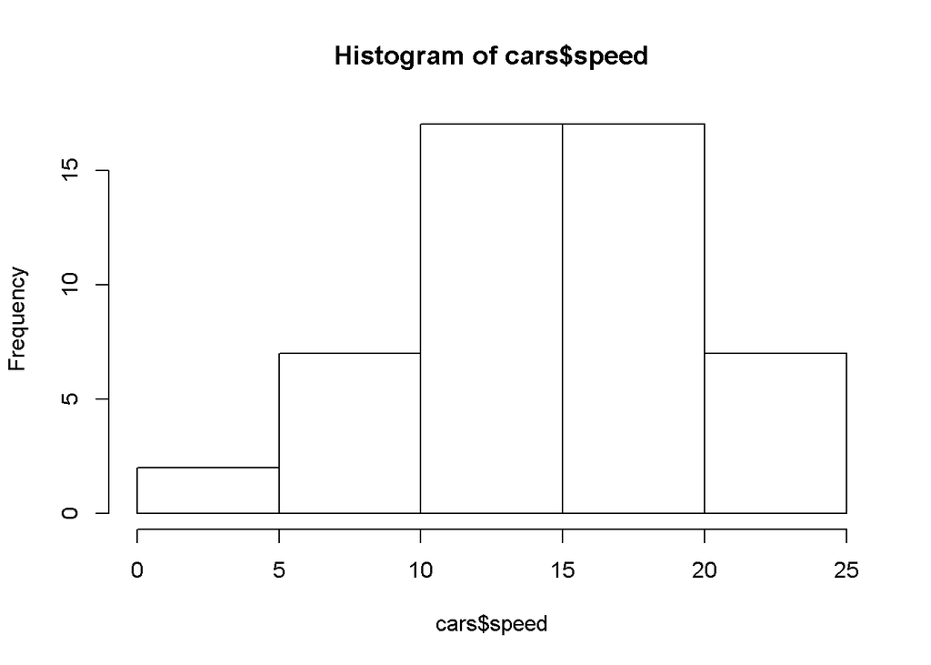

```r
hist(cars$speed) # Histogram
```

]

.pull-right[

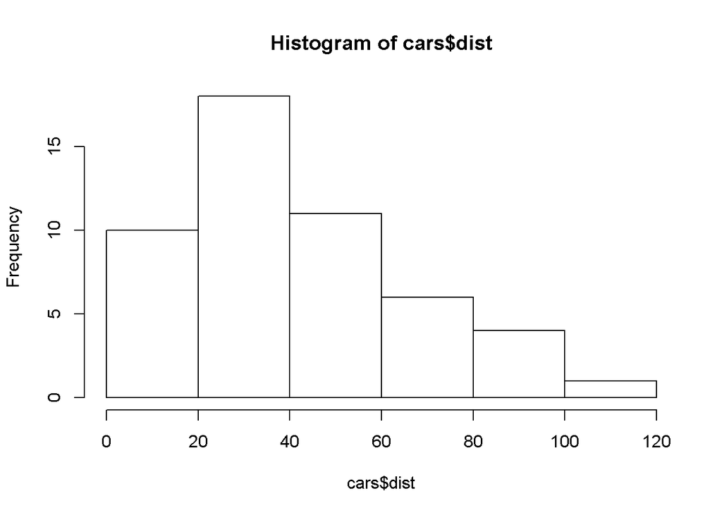

```r
hist(cars$dist)
```

]

## Drawing Slightly Less Ugly Pictures

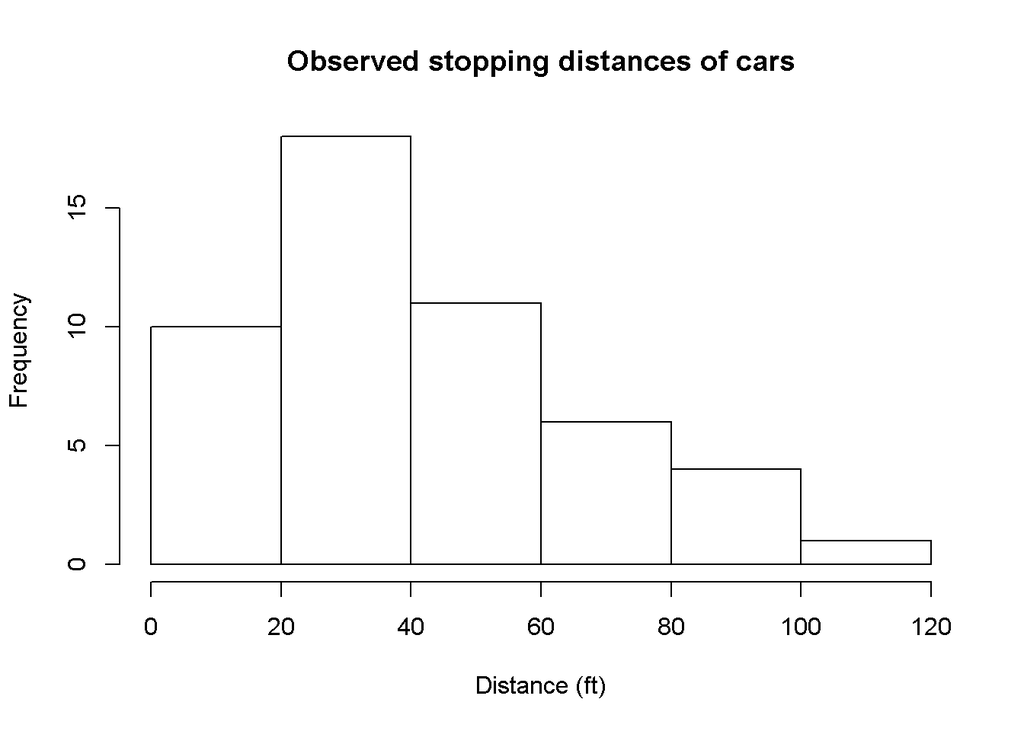

```r
hist(cars$dist,
     xlab = "Distance (ft)", # X axis label
     main = "Observed stopping distances of cars") # Title
```

# Math with `cars`

## If you put an assignment such as `x <- y` in parentheses `()`, R will print the output of the assignment out for you in your document. Otherwise, it won’t show the value.

```r
( dist_mean  <- mean(cars$dist) )
```

```
## [1] 42.98
```

```r
( speed_mean <- mean(cars$speed) )
```

```
## [1] 15.4
```

# Drawing Still Ugly Pictures

.small[

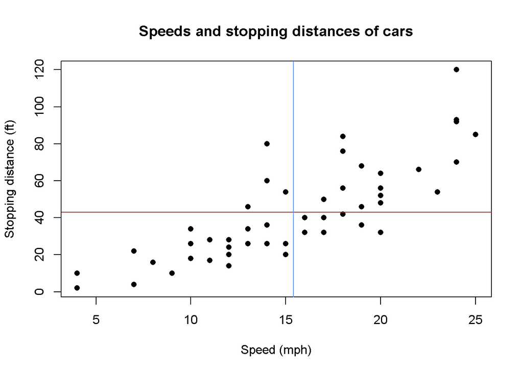

```r
plot(dist ~ speed, data = cars, #<<
     xlab = "Speed (mph)",
     ylab = "Stopping distance (ft)",
     main = "Speeds and stopping distances of cars",
     pch = 16) # Point size
abline(h = dist_mean, col = "firebrick")
abline(v = speed_mean, col = "cornflowerblue")
```

]

.pull-right[ .footnote[Note that `dist ~ speed` is a **formula** of the type `y ~ x`. The first element (`dist`) gets plotted on the y-axis and the second (`speed`) goes on the x-axis. Regression formulae follow this convention as well!]]

# `swiss` Time

Let’s switch gears to the `swiss` data frame built in to R.

–

First, use `?swiss` to see what things mean.

–

Then, load it using `data(swiss)`

–

Add chunks to your R Markdown document inspecting swiss, defining variables, doing some exploratory plots using hist or plot.

You might experiment with [colors](http://www.stat.columbia.edu/~tzheng/files/Rcolor.pdf) and [shapes](http://www.cookbook-r.com/Graphs/Shapes_and_line_types/).

## Looking at `swiss`

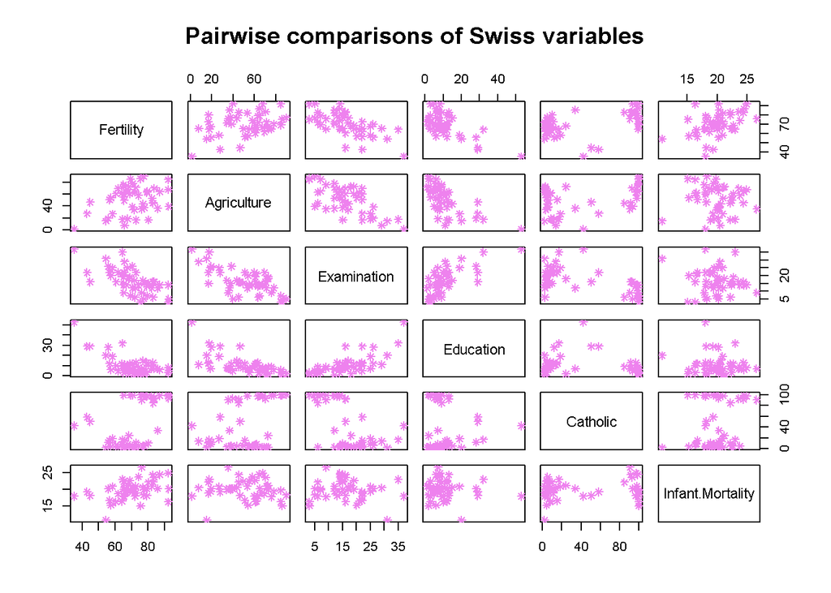

```r
pairs(swiss, pch = 8, col = "violet", #<<
      main = "Pairwise comparisons of Swiss variables")
```

.pull-right30[ .footnote[`pairs()` is a pairwise scatterplot function. Good for a quick look at small datasets, but mostly useless for larger data.]]

# Installing Packages

Let’s make a table that looks a little less code-y in the output. To do this, we’ll want to install a **package** called `pander`. Packages contain premade functions and/or data we can use. R’s strength is its wide variety of packages!

In the console: `install.packages("pander")`.

–

- Note that unlike the `library()` command, *the name of a package to be installed must be in quotes*. This is because the name here is a search term (text, not an object!) while for `library()` it is an actual R object.

–

- Once you install a package, you don’t need to re-install it until you update R. *Consequently, you should not include* `install.packages()` *in any markdown document or R script!*

# Making Tables

```r
library(pander) # loads pander, do once in your session
pander(summary(swiss), style = "rmarkdown", split.tables = 120) #<<
```

.small[

| Fertility | Agriculture | Examination | Education | Catholic | Infant.Mortality |
| --- | --- | --- | --- | --- | --- |
| Min. :35.00 | Min. : 1.20 | Min. : 3.00 | Min. : 1.00 | Min. : 2.150 | Min. :10.80 |
| 1st Qu.:64.70 | 1st Qu.:35.90 | 1st Qu.:12.00 | 1st Qu.: 6.00 | 1st Qu.: 5.195 | 1st Qu.:18.15 |
| Median :70.40 | Median :54.10 | Median :16.00 | Median : 8.00 | Median : 15.140 | Median :20.00 |
| Mean :70.14 | Mean :50.66 | Mean :16.49 | Mean :10.98 | Mean : 41.144 | Mean :19.94 |
| 3rd Qu.:78.45 | 3rd Qu.:67.65 | 3rd Qu.:22.00 | 3rd Qu.:12.00 | 3rd Qu.: 93.125 | 3rd Qu.:21.70 |
| Max. :92.50 | Max. :89.70 | Max. :37.00 | Max. :53.00 | Max. :100.000 | Max. :26.60 |

]

.footnote[Note that we put the `summary(swiss)` function call inside the `pander()` call. This is called *nesting functions* and is very common. I’ll introduce a method next week to avoid confusion from nesting too many functions inside each other.]

## Data Look a Little Nicer This Way

```r
pander(head(swiss, 5), style = "rmarkdown", split.tables = 120)
```

.small[

|  | Fertility | Agriculture | Examination | Education | Catholic | Infant.Mortality |
| --- | --- | --- | --- | --- | --- | --- |
| **Courtelary** | 80.2 | 17 | 15 | 12 | 9.96 | 22.2 |
| **Delemont** | 83.1 | 45.1 | 6 | 9 | 84.84 | 22.2 |
| **Franches-Mnt** | 92.5 | 39.7 | 5 | 5 | 93.4 | 20.2 |
| **Moutier** | 85.8 | 36.5 | 12 | 7 | 33.77 | 20.3 |
| **Neuveville** | 76.9 | 43.5 | 17 | 15 | 5.16 | 20.6 |

## ]

class: inverse

# Homework

Write up a .Rmd file showing some exploratory analyses of the Swiss fertility data. Upload both the `.Rmd` file and the `.html` file to Canvas. You must upload *both* for credit.

Mix in-line R calculations, tables, R output, and plots with text describing the relationships you see. Include *at least* one plot and one table. You are encouraged to include more! You must use in-line R calculations/references at least once (e.g. with functions like `nrow()`, `mean()`, `sd()`, `cor()`, `median()`, `min()`, `quantile()`) and *may not hard-code any numbers referenced in your text*.

Your document should be pleasant for a peer to look at, with some organization using sections or lists, and all plots labeled clearly. Use chunk options `echo` and `results` to limit the code/output you show in the .html. Discussion of specific values should be summarized in sentences in your text—*not as printed code and output*—and rounded so as not to be absurdly precise (e.g. round `x` with `round(x, 2)`).

### DUE: 11:59 PM, Tuesday, October 2nd, 2018

# Grading Rubric

0 - Didn’t turn anything in.

–

1 - Turned in but low effort, ignoring many directions.

–

2 - Decent effort, followed directions with some minor issues.

–

3 - Nailed it!